# RSY: MC1

## 7.3 UBCF mit ordinalem (Cosine Similarity) vs UBCF mit binärem Rating (Jaccard Similarity) für alle Testkunden.

**Hypothese:** Die beiden Recommender sind unterschiedlicher wie die bis anhin untersuchten. Somit sollten sie deutlich weniger Überschneidungen aufweisen.

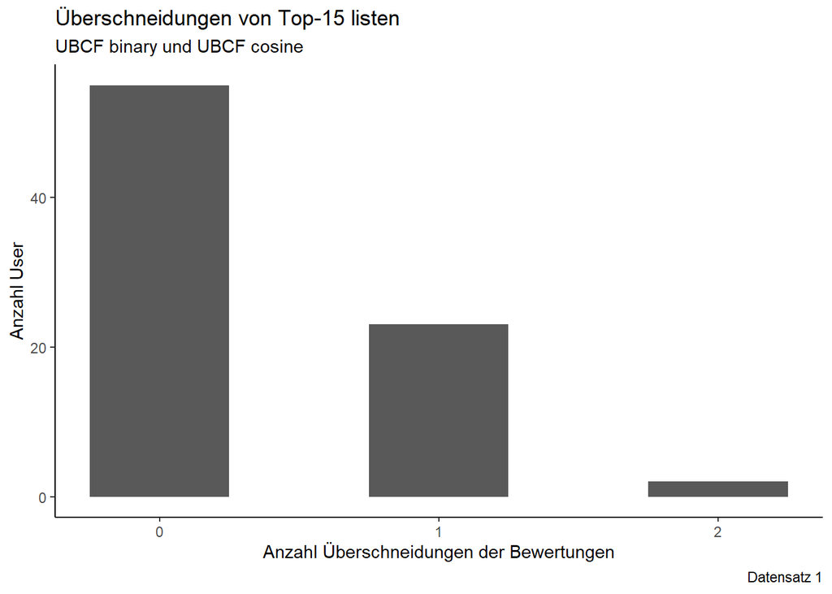

```r
intersection_Top15(pUBCF1,pUBCF_binary1,"UBCF binary","UBCF cosine","1")
```

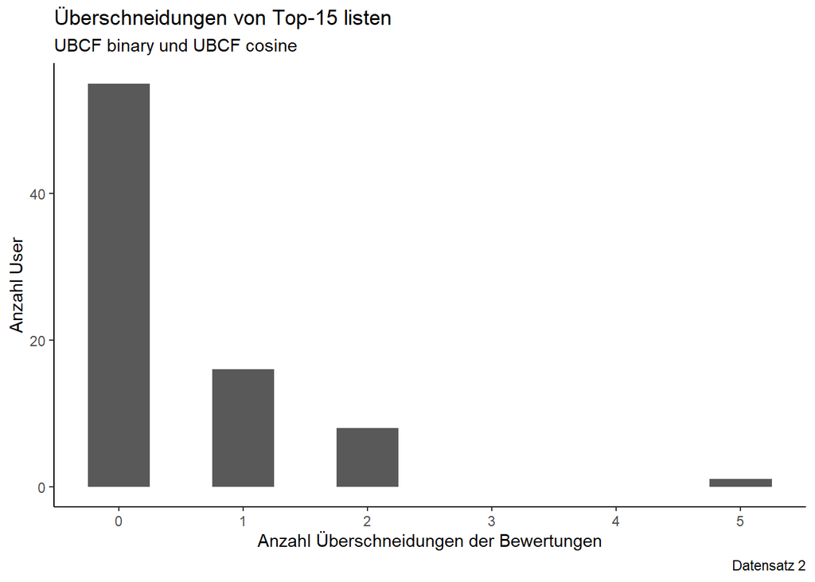

```r
intersection_Top15(pUBCF2,pUBCF_binary2,"UBCF binary","UBCF cosine","2")
```

**Beschreibungen:** Es hat fast keine Überschneidungen. Im zweiten Datensatz hat ein User 5 Filme in beiden Top-N Listen.

**Schlussfolgerung:** Die Hypothese kann angenommen werden. Es hat aber nur leicht weniger Überschneidungen, wie beim Vergleich mit ordinalen Ratings und Kosinus Ähnlichkeiten.

## 7.4 IBCF (Na_as_zeros = FALSE) vs IBCF (Na_as_zeros = TRUE)

Zusätzlich zu den Aufgaben wird noch überprüft ob es ein Unterschied macht wenn die NA gelöscht werden. (Anstatt mit 0 überschrieben)

**Hypothese:** Die Überschneidungen sollten gross sein.

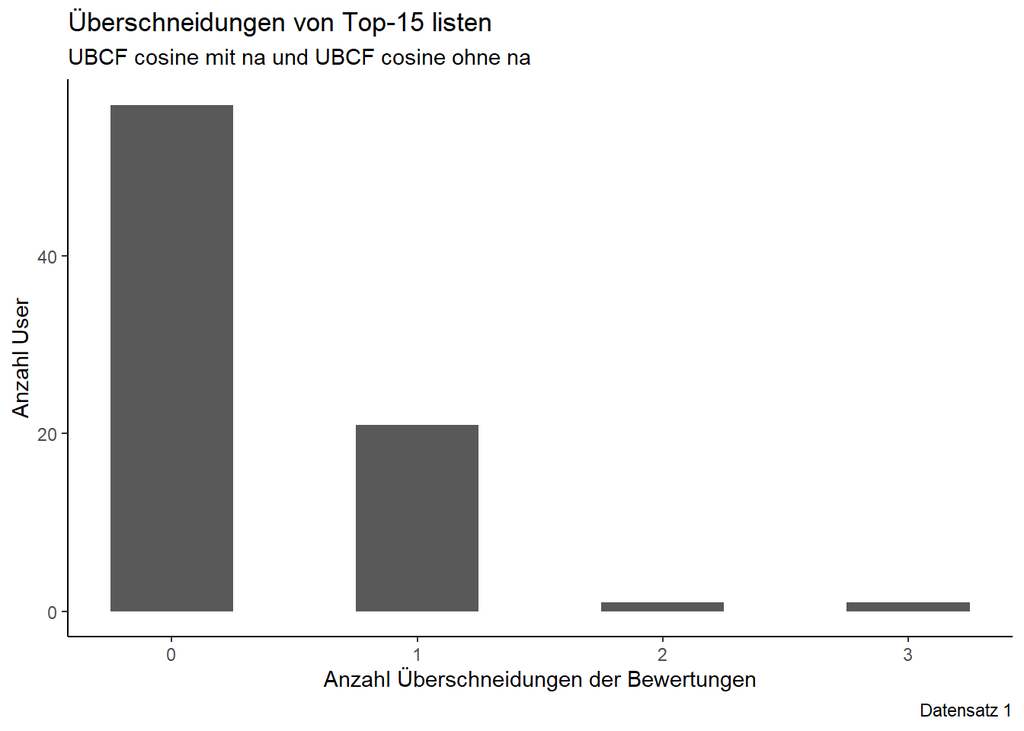

```r
IBCF1_na_false <- Recommender(as(training2, "realRatingMatrix"), "IBCF",
  param = list(normalize = NULL, method = "cosine", k = 30,na_as_zero = FALSE)
)
pIBCF1_na_false <- predict(IBCF1_na_false, as(test1, "realRatingMatrix"), type = "topNList", n = 15)

intersection_Top15(pIBCF1_na_false,pIBCF1,"UBCF cosine mit na","UBCF cosine ohne na","1")
```

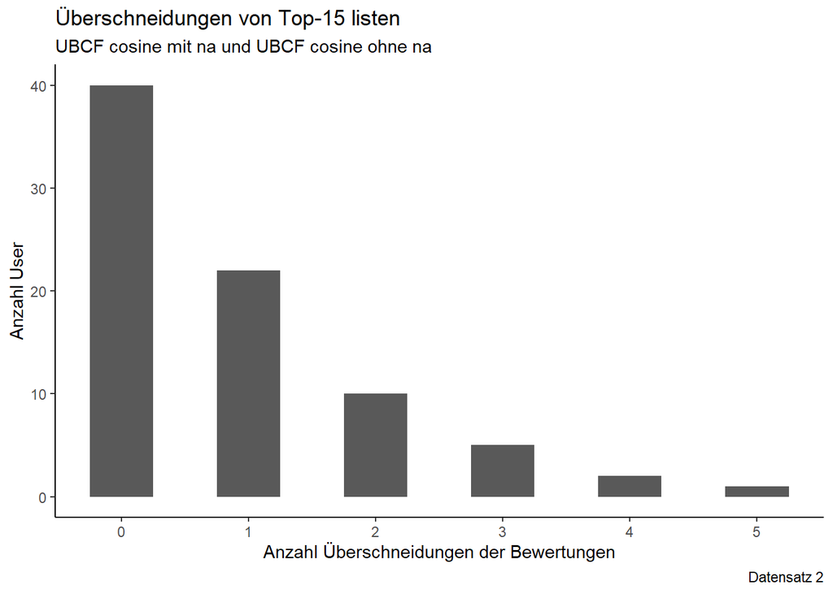

```r
IBCF2_na_false <- Recommender(as(training2, "realRatingMatrix"), "IBCF",
  param = list(normalize = NULL, method = "cosine", k = 30,na_as_zero = FALSE)
)
pIBCF2_na_false<- predict(IBCF2_na_false, as(test2, "realRatingMatrix"), type = "topNList", n = 15)
intersection_Top15(pIBCF2_na_false,pIBCF2,"UBCF cosine mit na","UBCF cosine ohne na","2")
```

**Beschreibung:** Im ersten Datensatz sind die Überschneidungen klein. Die meisten User haben 0 Überschneidungen. Im zweiten Datensatz hat es deutlich mehr Überschneidungen.

**Schlussfolgerung:** Die Hypothese wird abgelehnt. Es hat einen Einfluss, ob die NA-Werte auf 0 gesetzt werden oder gelöscht werden. Wenn die NA auf 0 gesetzt werden wird die Ähnlichkeit tendenziell kleiner. Da bei der Kosinus Ähnlichkeit der Nenner grösser wird und der Zähler nicht. Es macht Sinn das die Ähnlichkeit kleiner ist, wenn es wenig übereinstimmende Ratings hat.

## 7.5 Allgemeine Schlussfolgerung

Bei dieser Aufgabe wurde erkannt, dass das Resultat je nach Einstellungen des Recommender, sehr unterschiedlich sein kann. Um herauszufinden welcher Recommender gut ist, müssen diese Evaluiert werden. Dies wird in den Aufgabe 9 und 10 genauer untersucht.

# 8 Analyse Top-N Listen - IBCF vs SVD

In diesem Abschnitt wird ein IBCF Recommender mit einem SVD Recommender verglichen. Der SVD Recommender wird mit 10,20,30,40 und 50 Singulärwerten ausgeführt.

**Hypothese** Je mehr Singulärwerte verwendet werden, desto grösser werden die Überschneidungen

```r
SVD_pred <- function(train_data, test_data,singular_value) {

SVD1 <- Recommender(as(train_data, "realRatingMatrix"), "SVD",
  param = list( k = singular_value)
)
PSVD1<- predict(SVD1, as(test_data, "realRatingMatrix"), type = "topNList", n = 15)
return(PSVD1)
}
```

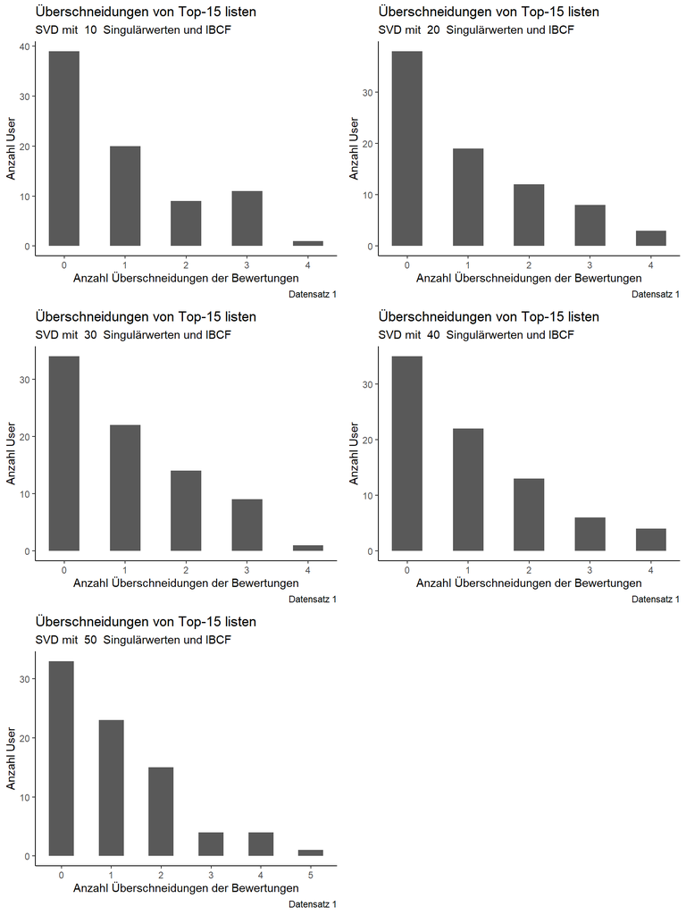

```r
# Sample 1
p <- list()
i = 1
for (singular_value in c(10,20,30,40,50)){
  p[[i]] <- intersection_Top15(pIBCF1,SVD_pred(training1,test1,singular_value),paste("SVD mit ",singular_value, " Singulärwerten"),"IBCF","1",TRUE)
  i <- i + 1
}
do.call(grid.arrange,c(p, ncol=2))
```

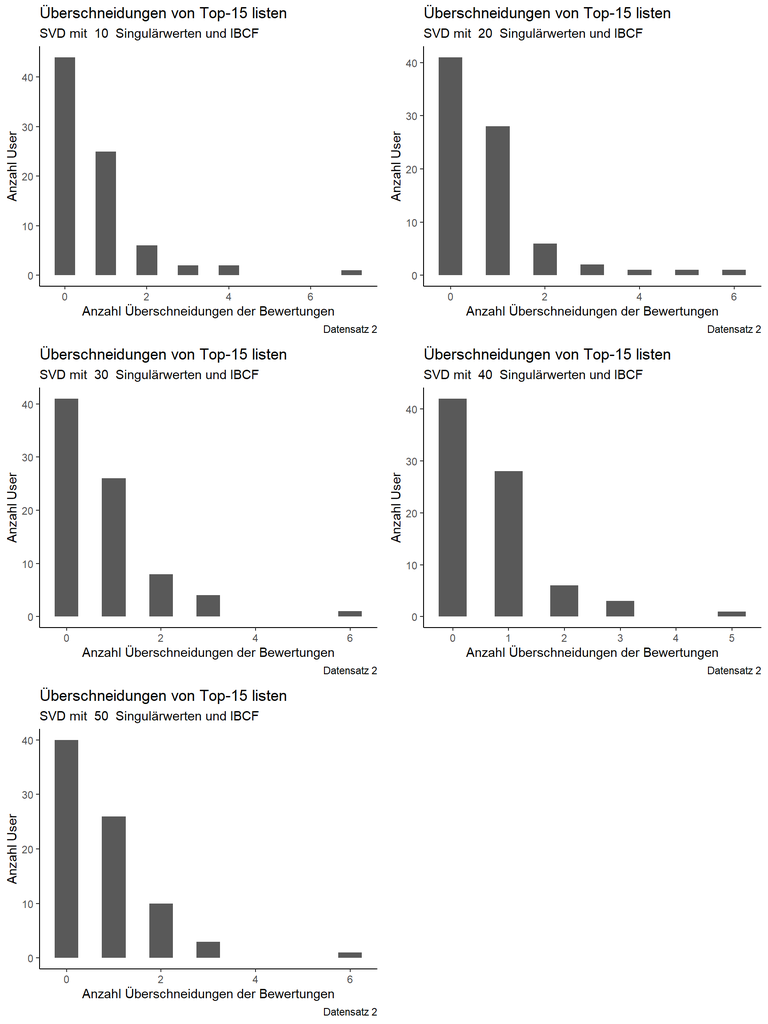

```r
# Sample 2
p <- list()
i = 1
for (singular_value in c(10,20,30,40,50)){
  p[[i]] <- intersection_Top15(pIBCF2,SVD_pred(training2,test2,singular_value),paste("SVD mit ",singular_value, " Singulärwerten"),"IBCF","2",TRUE)
  i <- i + 1
}
do.call(grid.arrange,c(p, ncol=2))
```

**Beschreibung:** Die Überschneidungen sind im allgemeinen nicht gross. Mit steigendem Singulärwert nehmen die Überschneidungen zu. Im Datensatz 1 nehmen sie stärker zu wie im Datensatz 2

**Schlussfolgerung:** Die Hypothese kann somit angenommen werden. Je weniger die Daten komprimiert (mehr Singulärwerte) werden, desto mehr Überschneidungen sind mit dem IBCF Recommender vorhanden.

# 9 Implementierung Top-N Metriken

Die Metriken werden nach folgenden Fomeln implementiert https://spaces.technik.fhnw.ch/spaces/recommender-systems/beitraege/recommender-system-evaluierung-coverage-und-novelty-1

## 9.1 Funktion Coverage

```r
coverage <- function(model){
predTopN <- as.data.frame(as(model, "matrix"))
predTopN$user <- rownames(predTopN)
predTopN <- pivot_longer(predTopN, cols = -c(user), values_drop_na = TRUE)

return(length(unique(predTopN$name))/700)
}
```

```r
calc_IBCF <- function(data,top_n){
IBCF_full1 <- Recommender(as(as.matrix(data), "realRatingMatrix"), "IBCF",
  param = list(normalize = NULL, method = "cosine", k = 30,na_as_zero = TRUE)
)
pIBCF_full1<- predict(IBCF_full1, as(as.matrix(data), "realRatingMatrix"), type = "topNList", n = top_n)
return(pIBCF_full1)
}
```

**Kurzbeschrieb Coverage**

Die Metrik Coverage zeigt wie Gross der Anteil von allen Filmen ist, die vorgeschlagen werden. Anhand von dieser Metrik kann man gut erkennen, ob die meisten Filmen für einen Vorschlag in Betracht gezogen werden. Mit dieser Metrik kann nicht getestet werden, wie oft die einzelnen Filme vorgekommen sind. Es könnte immer noch sein, dass ein Film bei allen Top-N Listen vorkommt.

## 9.2 Funktion Novelty

```r
# calc popularity sample 1
log_popularity1 <- ratings1 %>%
  group_by(movieId) %>%
  summarise(log_pop = log(n()/400))
```

```r
# calc popularity sample 2
log_popularity2 <- ratings2%>%
  group_by(movieId)%>%
  summarise(log_pop = log(n()/400))
```

```r
novelty <- function(model,log_popularity,topn,num_user = 400){
predTopN <- as.data.frame(as(model, "matrix"))
predTopN$user <- rownames(predTopN)
predTopN <- pivot_longer(predTopN, cols = -c(user), values_drop_na = TRUE) %>%
  rename(movieId = name)
predTopN <- transform(predTopN, movieId = as.numeric(movieId))
pred_with_log <- left_join(predTopN,log_popularity,by = "movieId")
return(-sum(pred_with_log$log_pop)/num_user/topn)
}
```

**Kurzbeschrieb Novelty**

Mit dieser Metrik kann aufgezeigt werden, wieviel neues eine Recommender hervorbringt. Durch die Popularity wird ein Bezug auf die Testdaten genommen.

## 9.3 Test von den System-Metriken

```r
novelty1 = c()
novelty2 = c()
coverage1 = c()
coverage2 = c()
topn = c( 5, 10, 15,20,25,30)
for (TopN in topn){
  novelty1 <- append(novelty1,novelty(calc_IBCF(m_user_item_r1,TopN),log_popularity1,TopN))
  coverage1 <- append(coverage1,coverage(calc_IBCF(m_user_item_r1,TopN)))
  novelty2 <- append(novelty2,novelty(calc_IBCF(m_user_item_r2,TopN),log_popularity2,TopN))

  coverage2 <- append(coverage2,coverage(calc_IBCF(m_user_item_r2,TopN)))

}
```

```r
cov_novel1 <- as.data.frame(list(coverage1,novelty1,topn), col.names = c("cov","novel","topn"))
cov_novel2 <- as.data.frame(list(coverage2,novelty2,topn), col.names = c("cov","novel","topn"))
```

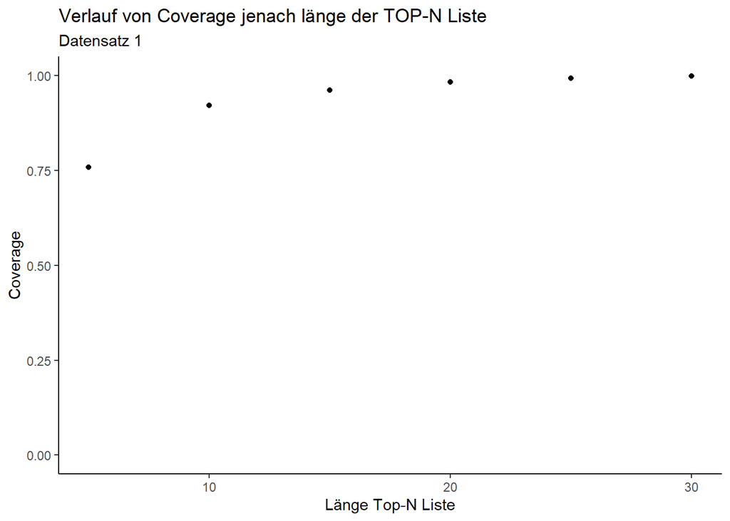

```r
ggplot(cov_novel1,aes(topn,cov))+
  geom_point()+
  ylim(0,1) +
  labs(
    title = "Verlauf von Coverage jenach länge der TOP-N Liste",
    x = "Länge Top-N Liste",
    y = "Coverage",
    subtitle = "Datensatz 1"
  ) +
  theme_classic()
```

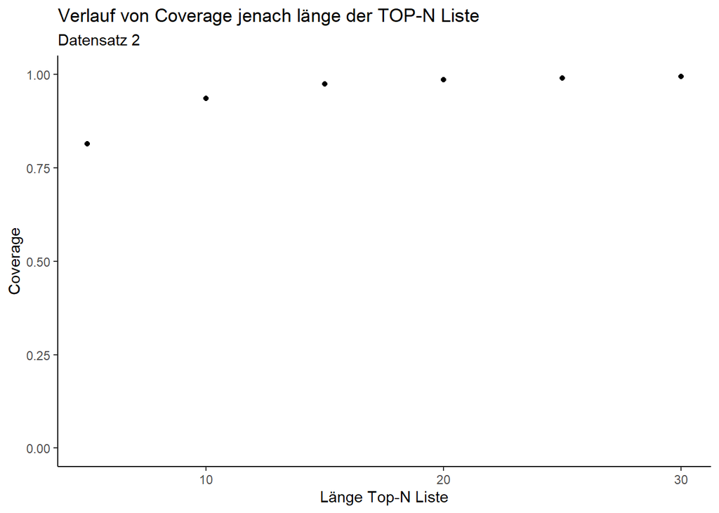

```r
ggplot(cov_novel2,aes(topn,cov))+
  geom_point()+
  ylim(0,1) +
  labs(
    title = "Verlauf von Coverage jenach länge der TOP-N Liste",
    x = "Länge Top-N Liste",
    y = "Coverage",
    subtitle = "Datensatz 2"
  ) +
  theme_classic()
```

**Beschreibung Coverage**

Die Coverage steigt bis zu der Top- 15 Liste stark an. Danach bleibt die Coverage bei nahezu 1 bestehen.

**Interpretation**

Der Recommender deckt ab einer Top- 15 Liste nahezu alle Filme ab. Somit gibt es keine grössere Anzahl von Filmen, welche ausgelassen werden.

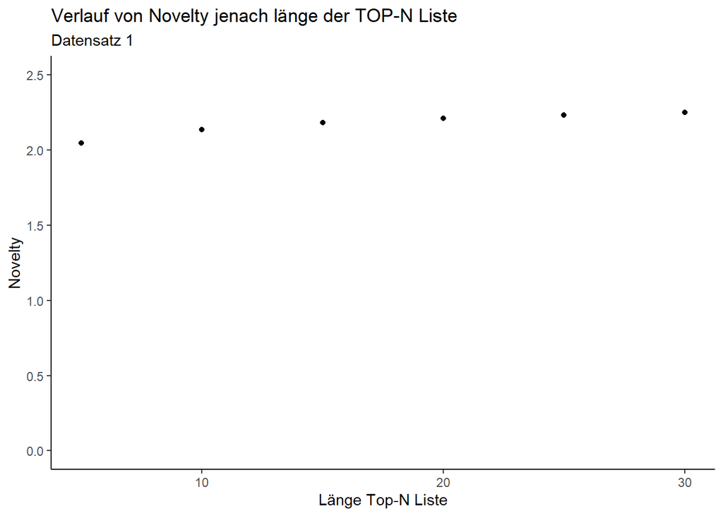

```r
ggplot(cov_novel1,aes(topn,novel))+
  geom_point()+
  ylim(0,2.5) +
  labs(
    title = "Verlauf von Novelty jenach länge der TOP-N Liste",
    x = "Länge Top-N Liste",
    y = "Novelty",
    subtitle = "Datensatz 1"
  ) +
  theme_classic()
```

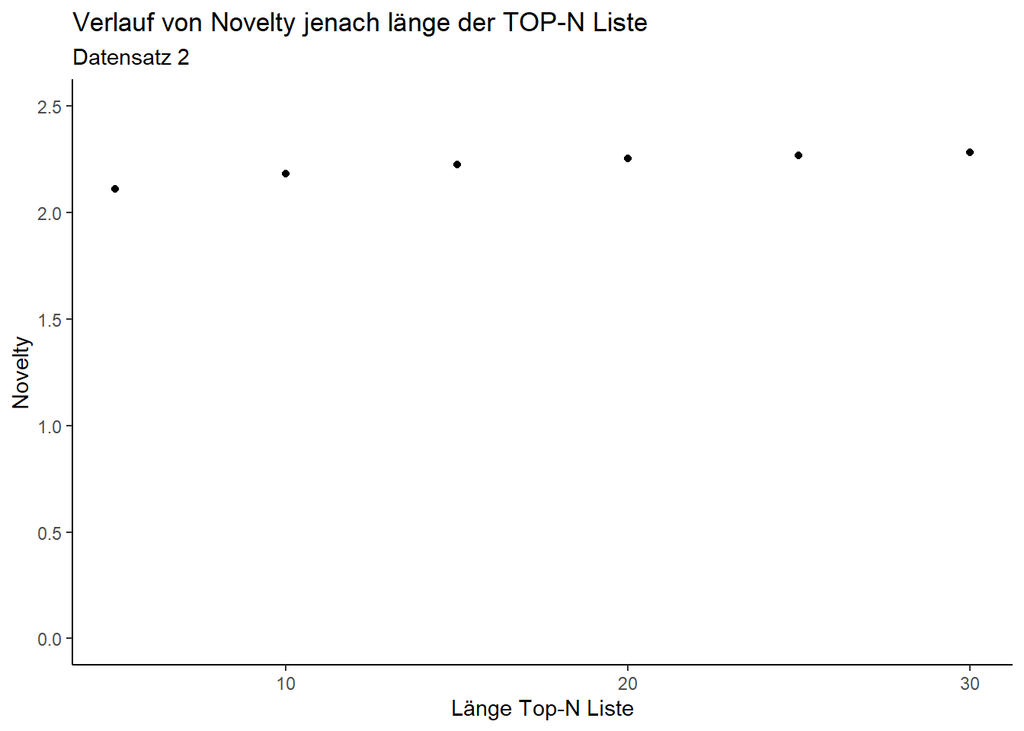

```r
ggplot(cov_novel2,aes(topn,novel))+
  geom_point()+
  ylim(0,2.5) +
  labs(
    title = "Verlauf von Novelty jenach länge der TOP-N Liste",
    x = "Länge Top-N Liste",
    y = "Novelty",
    subtitle = "Datensatz 2"
  ) +
  theme_classic()
```

# 10 Wahl des optimalen Recommenders

## 10.1 10-Fache Krossvalidierung

Im folgenden wird eine 10-Fache Krossvalidierung. Damit eine Aussage gemacht werden kann, wurde eine minimale Anzahl von 3 Ratings bestimmt. Diese sollten jeweils in den Trainingsdaten vorhanden sein.

```r
#sample 1
scheme1 <-  evaluationScheme(as(as.matrix(m_user_item_r1),"realRatingMatrix"), method="cross-validation",k=10, given = 3,goodRating  = 0)
scheme_binary1 <- evaluationScheme(binarize(as(as.matrix(m_user_item_r2),"realRatingMatrix"),0), method="cross-validation",k=10, given = 3,goodRating  = 0)
```

```r
#sample 2
scheme2 <-  evaluationScheme(as(as.matrix(m_user_item_r2),"realRatingMatrix"), method="cross-validation",k=10, given = 3, goodRating  = 0)
```

## 10.2 Begründung der Modelle und Metriken

**Metriken:** Als Testmetriken wird Precision, Novelty und Coverage verwendet. Precision wird verwendet, damit möglichst viele gute Filme in den Top-N Listen vorhanden sind. Novelty damit neue Erkentnisse aus den Daten gezogen werden können und Coverage um zu sehen, wie gross der Anteil ist von Filmen, die abgedeckt werden.

## 10.3 Analyses des besten Modelles

### 10.3.1 Precision

```r
# Sample 1
algorithms <- list(
  "user-based CF" = list(name="UBCF", param=list(method="Cosine",
                                                 nn = 20
                                                 )),
  "item-based CF" = list(name="IBCF", param=list(k = 20,
                                                 method = "cosine"
                                                 )),
  "Binary user-based CF" = list(name = "IBCF", param = list(k= 20,
                                                          method = "jaccard")),
  "Binary item-based CF" = list(name = "UBCF", param = list(nn=20,
                                                          method = "jaccard")),
  "SVD" = list(name = "SVD",param = list(k= 30))


  )

# run algorithms, predict next n movies
topn <- c(10, 15, 20, 25, 30)
results <- evaluate(scheme1, algorithms,type="topNList" , n= topn)
```

```r
# Sample 1
# Precision extrahieren
alg_names <- names(algorithms)
precision <- as.data.frame({})
for (model in 1:length(alg_names)){
  model_select <- getResults(results[[model]])
  precision_split <- as.data.frame({})
for (split in 1:10){
precision_split <- rbind(precision_split,select(as.data.frame(model_select[[split]]),c("precision","n")))
}
precision_split$model <- alg_names[[model]]
precision <- rbind(precision,precision_split)
}


# Standartabweichung und durchschnitt der 10 kfolds berechnen.
precision <- precision %>%
group_by(model,n)%>%
  summarise(mean_prec = mean(precision),
            sd_prec = sd(precision))
```

**Top Movie Recommender**

Der Top Movie Recommender schlägt bei jedem User die Filme vor mit dem höchsten Durchschnittsrating über dem ganzen Datensatz.

```r
# sample 1
# Top Movie Recommender
top_n_movies1 <- user_item_r1%>%
  group_by(movieId)%>%
  summarise(mean_rating = mean(z_rating)) %>%
  arrange(desc(mean_rating))%>%
  head(30)%>%
  rename(name = movieId)
class(top_n_movies1$name) <- "character"

top_n <- top_n_movies1$name

prec_best_mean <- as.data.frame({})

for (n in topn){
  prec_fold = list()
    for (n_split in 1:10){

    pred_movies <- getData(scheme1,"unknown",run = n_split)
    pred_movies <- as.data.frame(as(pred_movies,"matrix"))
    pred_movies$username <- rownames(pred_movies)
    pred_movies_long <- pivot_longer(pred_movies, cols = -c(username), values_drop_na = TRUE)

    prec <- nrow(pred_movies_long %>%
       filter(name %in% top_n[1:n]))/n/40

    prec_fold <- append(prec_fold,prec)

    }
  prec_best_mean <-rbind(prec_best_mean,as.data.frame(list(mean(unlist(prec_fold)),sd(unlist(prec_fold)),n,"Top Movie"),col.names = c("mean_prec","sd_prec","n","model")))
  }

precision <- rbind(precision,prec_best_mean)

precision$type <- "precision"
```

**Precision Visualisieren**

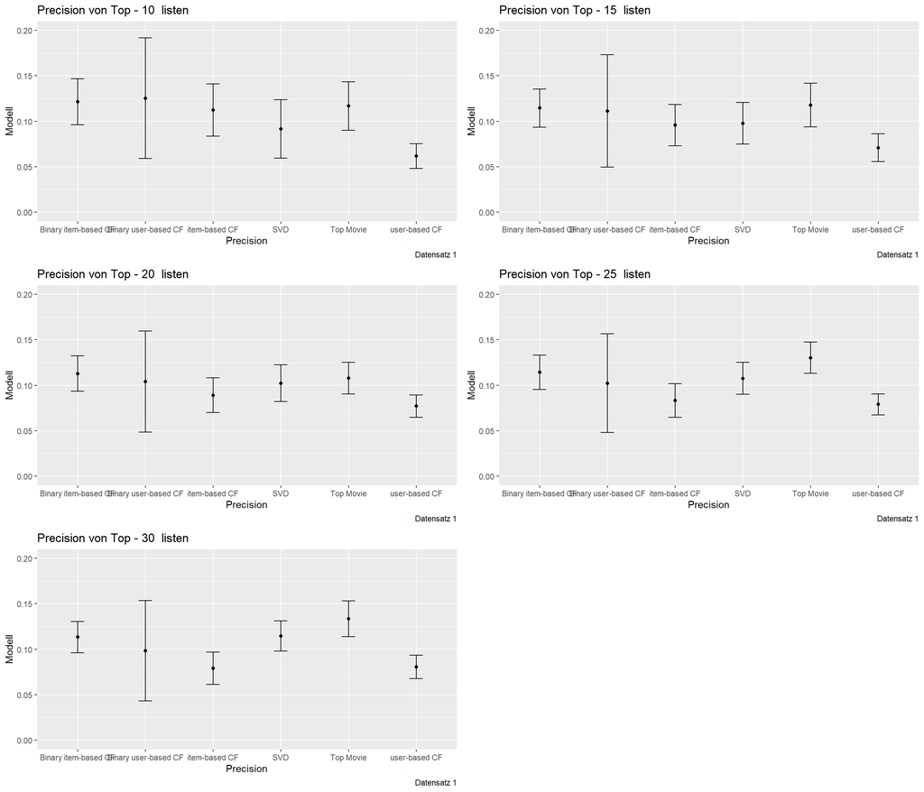

```r
# plot
p <- list()
i = 1
for (n_value in topn){
  pre_plot <- filter(precision,n == n_value)
plot <- (ggplot(pre_plot, aes(x=model, y= mean_prec)) +
  geom_point() +
  geom_errorbar(aes(ymin=mean_prec- sd_prec, ymax=mean_prec+sd_prec), width=.2,
                 position=position_dodge(.9))+
  ylim(0,0.2)+
    labs(
    title = paste("Precision von Top -",n_value," listen"),
    x = "Precision",
    y = "Modell",
    caption = "Datensatz 1"))
   p[[i]] <- plot

   i = i + 1
}
do.call(grid.arrange,c(p, ncol=2))
```

```r
# Sample 2
# run algorithms, predict next n movies
results <- evaluate(scheme2, algorithms,type="topNList" , n= topn)
```

```r
# Sample 2
# Precision extrahieren
precision2 <- as.data.frame({})
for (model in 1:length(alg_names)){
  model_select <- getResults(results[[model]])
  precision_split <- as.data.frame({})
for (split in 1:10){
precision_split <- rbind(precision_split,select(as.data.frame(model_select[[split]]),c("precision","n")))
}
precision_split$model <- alg_names[[model]]
precision2 <- rbind(precision2,precision_split)
}


# Standartabweichung und durchschnitt der 10 kfolds berechnen.
precision2 <- precision2 %>%
group_by(model,n)%>%
  summarise(mean_prec = mean(precision),
            sd_prec = sd(precision))
```

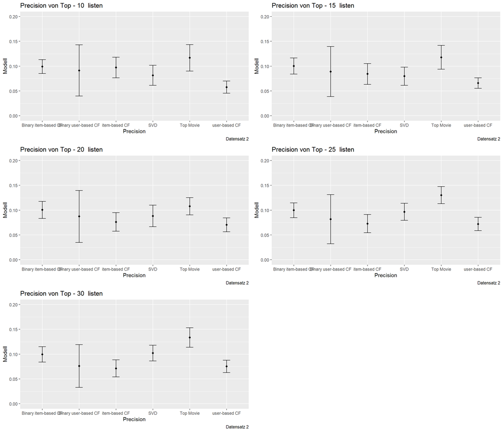

```r
# sample 2
# Basis Modell
top_n_movies2 <- user_item_r2%>%
  group_by(movieId)%>%
  summarise(mean_rating = mean(z_rating)) %>%
  arrange(desc(mean_rating))%>%
  head(30)%>%
  rename(name = movieId)
class(top_n_movies2$name) <- "character"

top_n <- top_n_movies2$name

prec_best_mean2 <- as.data.frame({})

for (n in topn){
  prec_fold = list()
    for (n_split in 1:10){

    pred_movies <- getData(scheme2,"unknown",run = n_split)
    pred_movies <- as.data.frame(as(pred_movies,"matrix"))
    pred_movies$username <- rownames(pred_movies)
    pred_movies_long <- pivot_longer(pred_movies, cols = -c(username), values_drop_na = TRUE)

    prec <- nrow(pred_movies_long %>%
       filter(name %in% top_n[1:n]))/n/40

    prec_fold <- append(prec_fold,prec)

    }
  prec_best_mean2 <-rbind(prec_best_mean2,as.data.frame(list(mean(unlist(prec_fold)),sd(unlist(prec_fold)),n,"pre_best_mean"),col.names = c("mean_prec","sd_prec","n","model")))
  }

precision2 <- rbind(precision2,prec_best_mean)


# plot
p2 <- list()
i = 1
for (n_value in topn){
  pre_plot <- filter(precision2,n == n_value)
plot <- (ggplot(pre_plot, aes(x=model, y= mean_prec)) +
  geom_point() +
  geom_errorbar(aes(ymin=mean_prec- sd_prec, ymax=mean_prec+sd_prec), width=.2,
                 position=position_dodge(.9))+
  ylim(0,0.2)+
    labs(
    title = paste("Precision von Top -",n_value," listen"),
    x = "Precision",
    y = "Modell",
    caption = "Datensatz 2"))
   p2[[i]] <- plot

   i = i + 1
}
do.call(grid.arrange,c(p2, ncol=2))
```

**Interpretation Precision:**

Die Modelle sind was die Precision anbelangt nicht alzu gut. Der Top-Movie Recommender ist gleich gut oder besser wie alle anderen Modelle. Eine mögliche Erklärung ist, dass das verwenden der standartisierten Ratings pro User nicht Sinnvoll waren.

### 10.3.2 Coverage Novelty berechnen

Coverage und Novelty von den unterschiedlichen Modellen berechnen.

```r
# sample 1
# novelty base model
top_n_movies1 <- top_n_movies1%>%rename(movieId = name)
class(top_n_movies1$movieId) <- "integer"
pred_with_log <- left_join(top_n_movies1
                           ,log_popularity1,by = "movieId")

novelty_best_mean_model =c()
for (n_value in topn){
  novelty_best_mean_model <- append(novelty_best_mean_model,(-sum(head(pred_with_log,n_value)$log_pop)/1/n_value))
}


# coverage base model
coverage_best_mean_model =c()
for (n_value in topn){
  coverage_best_mean_model <- append(coverage_best_mean_model,n_value/700)
}

# coverage & novelty recommender
novelty_values = as.data.frame({})
coverage_values = as.data.frame({})
i = 1
for (top in topn){
for (algorithm in algorithms){
  nov_fold = list()
  cov_fold = list()
  for (n_split in 1:10){
    trained_model <- Recommender(getData(scheme1,"train",run = n_split), algorithm$name,
  param = algorithm$param
)

# predict model
pred_model <- predict(trained_model, getData(scheme1,"unknown",run = n_split), type = "topNList", n = top)
nov_fold <- append(nov_fold,novelty(pred_model,log_popularity1,top,40))
cov_fold <- append(cov_fold,coverage(pred_model))
}
novelty_values <-rbind(novelty_values,as.data.frame(list(mean(unlist(nov_fold)),sd(unlist(nov_fold)),top,alg_names[[i%%5 + 1]]),col.names = c("mean_novel","sd_novel","n","model")))
coverage_values <- rbind(coverage_values,as.data.frame(list(mean(unlist(cov_fold)),sd(unlist(cov_fold)),top,alg_names[[i%%5 + 1]]),col.names = c("mean_cov","sd_cov","n","model")))
i = i + 1
}
}
```

```r
# sample 2
# novelty base model
top_n_movies2 <- top_n_movies2%>%rename(movieId = name)
class(top_n_movies2$movieId) <- "integer"
pred_with_log <- left_join(top_n_movies2
                           ,log_popularity2,by = "movieId")

novelty_best_mean_model2 =c()
for (n_value in topn){
  novelty_best_mean_model2 <- append(novelty_best_mean_model2,(-sum(head(pred_with_log,n_value)$log_pop)/1/n_value))
}

# coverage base model
coverage_best_mean_model2 =c()
for (n_value in topn){
  coverage_best_mean_model2 <- append(coverage_best_mean_model2,n_value/700)
}

# coverage & novelty recommender
novelty_values2 = as.data.frame({})
coverage_values2 = as.data.frame({})
i = 1
for (top in topn){
for (algorithm in algorithms){
  nov_fold = list()
  cov_fold = list()
  for (n_split in 1:10){
    trained_model <- Recommender(getData(scheme2,"train",run = n_split), algorithm$name,
  param = algorithm$param
)

# predict model
pred_model <- predict(trained_model, getData(scheme2,"unknown",run = n_split), type = "topNList", n = top)
nov_fold <- append(nov_fold,novelty(pred_model,log_popularity2,top,40))
cov_fold <- append(cov_fold,coverage(pred_model))
}
novelty_values2 <-rbind(novelty_values2,as.data.frame(list(mean(unlist(nov_fold)),sd(unlist(nov_fold)),top,alg_names[[i%%5 + 1]]),col.names = c("mean_novel","sd_novel","n","model")))
coverage_values2 <- rbind(coverage_values2,as.data.frame(list(mean(unlist(cov_fold)),sd(unlist(cov_fold)),top,alg_names[[i%%5 + 1]]),col.names = c("mean_cov","sd_cov","n","model")))
i = i + 1
}
}
```

### 10.3.3 Novelty Visualisieren

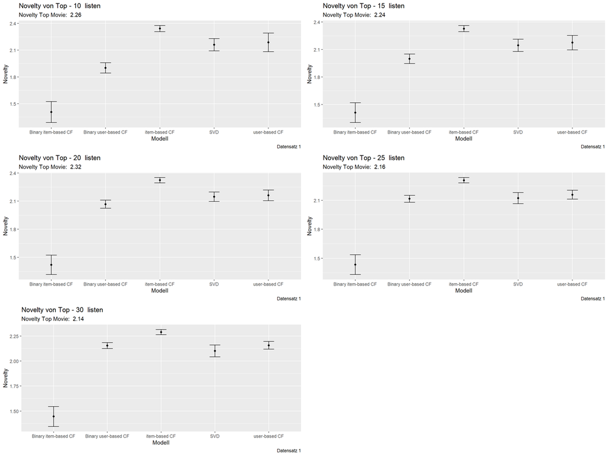

```r
p <- list()
i = 1
for (n_value in topn){
  pre_plot <- filter(novelty_values,n == n_value)
plot <- (ggplot(pre_plot, aes(x=model, y= mean_novel)) +
  geom_point() +
  geom_errorbar(aes(ymin=mean_novel- sd_novel, ymax=mean_novel+sd_novel), width=.2,
                 position=position_dodge(.9))+
    labs(
    title = paste("Novelty von Top -",n_value," listen"),
    subtitle = paste("Novelty Top Movie: ",round(novelty_best_mean_model[[i]],2)),
    x = "Modell",
    y = "Novelty",
    caption = "Datensatz 1"))
   p[[i]] <- plot

   i = i + 1
}

do.call(grid.arrange,c(p, ncol=2))
```

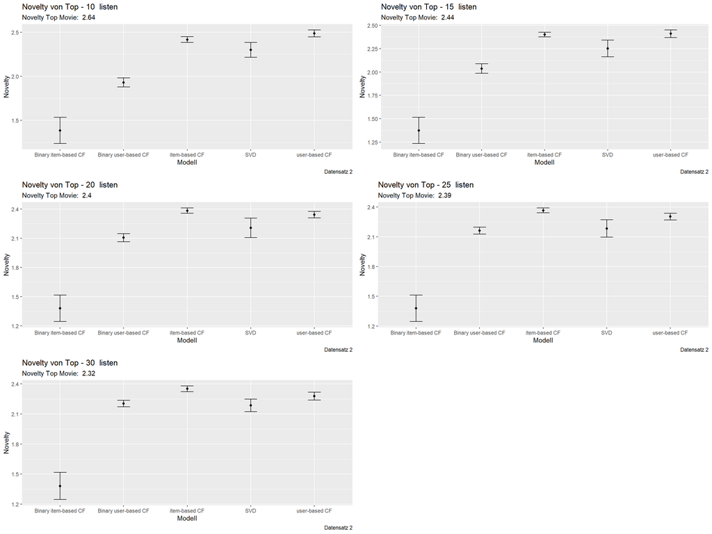

```r
p2 <- list()
i = 1
for (n_value in topn){
  pre_plot <- filter(novelty_values2,n == n_value)
plot <- (ggplot(pre_plot, aes(x=model, y= mean_novel)) +
  geom_point() +
  geom_errorbar(aes(ymin=mean_novel- sd_novel, ymax=mean_novel+sd_novel), width=.2,
                 position=position_dodge(.9))+

    labs(
    title = paste("Novelty von Top -",n_value," listen"),
    subtitle = paste("Novelty Top Movie: ",round(novelty_best_mean_model2[[i]],2)),
    x = "Modell",
    y = "Novelty",
    caption = "Datensatz 2"))
   p2[[i]] <- plot

   i = i + 1
}
do.call(grid.arrange,c(p2, ncol=2))
```

**Beobachtung:**

**Interpretation:**

Da die Filme im Top-Movie Recommender nicht alzu häufig im Datensatz vorkommen, ist die Novelty ähnlich hoch. Ansonsten fällt vorallem der Binary IBCF Recommender ab.

### 10.3.4 Coverage Visualisieren

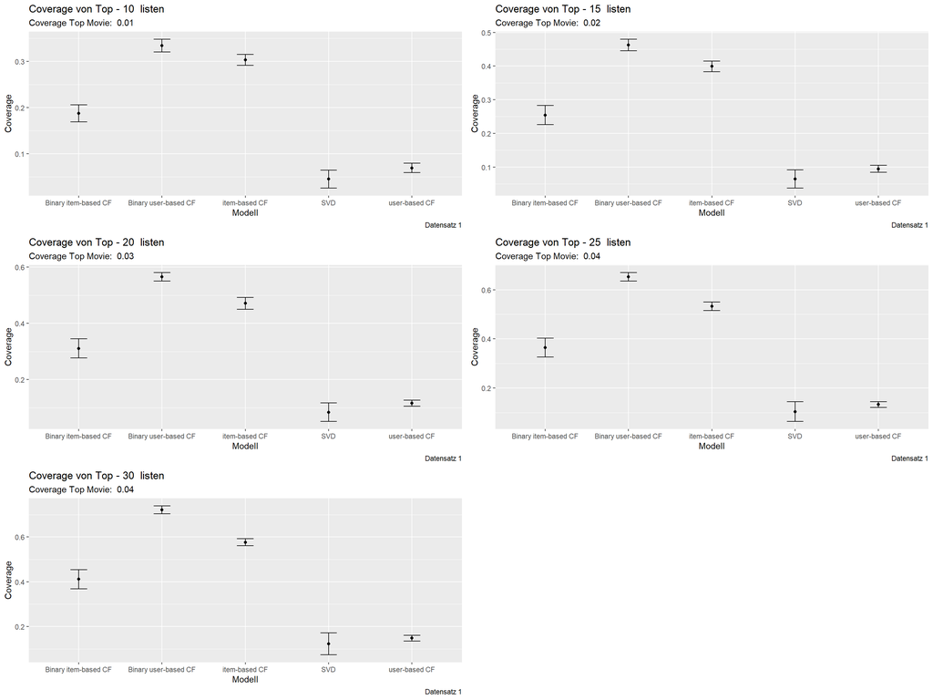

```r
# sample 1
# plot
p <- list()
i = 1
for (n_value in topn){
  pre_plot <- filter(coverage_values,n == n_value)
plot <- (ggplot(pre_plot, aes(x=model, y= mean_cov)) +
  geom_point() +
  geom_errorbar(aes(ymin=mean_cov- sd_cov, ymax=mean_cov+sd_cov), width=.2,
                 position=position_dodge(.9))+

    labs(
    title = paste("Coverage von Top -",n_value," listen"),
    subtitle = paste("Coverage Top Movie: ",round(coverage_best_mean_model[[i]],2)),
    x = "Modell",
    y = "Coverage",
    caption = "Datensatz 1"))
   p[[i]] <- plot

   i = i + 1
}
do.call(grid.arrange,c(p, ncol=2))
```

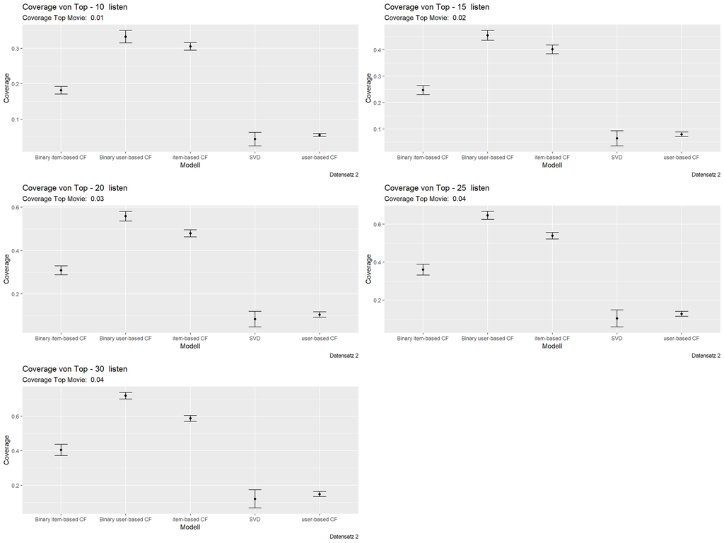

```r
# sample 2
# plot
p2 <- list()
i = 1
for (n_value in topn){
  pre_plot <- filter(coverage_values2,n == n_value)
plot <- (ggplot(pre_plot, aes(x=model, y= mean_cov)) +
  geom_point() +
  geom_errorbar(aes(ymin=mean_cov- sd_cov, ymax=mean_cov+sd_cov), width=.2,
                 position=position_dodge(.9))+

    labs(
    title = paste("Coverage von Top -",n_value," listen"),
    subtitle = paste("Coverage Top Movie: ",round(coverage_best_mean_model[[i]],2)),
    x = "Modell",
    y = "Coverage",
    caption = "Datensatz 2"))
   p2[[i]] <- plot

   i = i + 1
}
do.call(grid.arrange,c(p2, ncol=2))
```

**Beobachtung:**

Der Top Movie Recommender hat die tiefste Coverage. Ansonsten hat SVD und UBCF eine tiefe Coverage und Binary UBCF hat die höchste Coverage.

**Interpretation:**

Der Top-Movie Recommender deckt nur sehr wenige Filme ab, da jedesmal die gleichen Filme empfohlen werden.

### 10.3.5 Auswahl des Recommenders

Die IBCF Recommender ist der Kompromiss zwischen Novelty, Coverage und Precision. Der IBCF hebt sich vor allem mit eine guten Coverage und Novelty von den anderen Recommender ab.

## 10.4 Hyperparameter Trainieren

Das IBCF Modell hat zwei Hyperparameter. Die Anzahl Nachbarn und ob die NA auf 0 gesetzt werden. Die Hyperparameter werden mit der Top-N Liste von 10 und der Precision als Metrik gemacht. Die Precision wurde gewählt, weil der ausgewählte Recommender bei dieser Metrik am meisten abfallt. Es wäre auch möglich eine Kombination von Metriken zu wählen.

```r
# sample 1
best_precision <- 0
for (neighbours in (1:20)*2){
  for (na_as_zero in c(TRUE,FALSE)){
    algorithm_test <- list("item-based CF" = list(name="IBCF", param=list(method="Cosine",k=neighbours,na_as_zero = na_as_zero)))
    results_best_model <- evaluate(scheme1, algorithm_test, type="topNList" , n= 10)
    mean_precision <- avg(results_best_model)[[1]][[6]]
    if (best_precision < mean_precision) {
      best_precision <- mean_precision
      best_algorithm <- algorithm_test

    }
  }
}

algorithm_k1 <- best_algorithm$`item-based CF`$param$k
algorithm_na_as_zero1 = best_algorithm$`item-based CF`$param$na_as_zero
```

```r
# sample 1
nov_fold = list()
  cov_fold = list()
for (n_split in 1:10){
    trained_model <- Recommender(getData(scheme1,"train",run = n_split), best_algorithm[[1]]$name,
  param = best_algorithm[[1]]$param
)

# predict model
pred_model <- predict(trained_model, getData(scheme1,"unknown",run = n_split), type = "topNList", n = 10)
nov_fold <- append(nov_fold,novelty(pred_model,log_popularity1,top,40))
cov_fold <- append(cov_fold,coverage(pred_model))
}

nov_fold1 <- round(mean(unlist(nov_fold)),2)
cov_fold1 <- round(mean(unlist(cov_fold)),2)
best_precision <- round(best_precision,2)
```

```r
# sample 2
best_precision2 <- 0
for (neighbours in (1:20)*2){
  for (na_as_zero in c(TRUE,FALSE)){
    algorithm_test <- list("item-based CF" = list(name="IBCF", param=list(method="Cosine",k=neighbours,na_as_zero = na_as_zero)))
    results_best_model <- evaluate(scheme2, algorithm_test, type="topNList" , n= 10)
    mean_precision <- avg(results_best_model)[[1]][[6]]
    if (best_precision2 < mean_precision) {
      best_precision2 <- mean_precision
      best_algorithm2 <- algorithm_test

    }
  }
}
algorithm_k2 <- best_algorithm2$`item-based CF`$param$k
algorithm_na_as_zero2 = best_algorithm2$`item-based CF`$param$na_as_zero
```

```r
# sample 2
nov_fold = list()
cov_fold = list()
for (n_split in 1:10){
    trained_model <- Recommender(getData(scheme2,"train",run = n_split), best_algorithm2[[1]]$name,
  param = best_algorithm2[[1]]$param
)

# predict model
pred_model <- predict(trained_model, getData(scheme2,"unknown",run = n_split), type = "topNList", n = 30)
nov_fold <- append(nov_fold,novelty(pred_model,log_popularity2,top,40))
cov_fold <- append(cov_fold,coverage(pred_model))
}
```

```r
mean_nov2 <- round(mean(unlist(nov_fold)),2)
mean_cov2 <- round(mean(unlist(cov_fold)),2)
best_precision2 <- round(best_precision2,2)
```

**Beschreibung:** Beim Datensatz 1 erzielt der beste Algorithmus basierend auf der Precision, eine Precision von 0.16 eine Novelty von 0.71 und eine Coverage von 0.38. Dabei wurde der IBCF Recommender mit der Cosinus Ähnlichkeit, 40 Nachbarn und na_as_zero = TRUE

Beim Datensatz 2 ist die Coverage und Novelty hoch. Die Precision ist im Vergleich mittelmässig.

# 11 Implementierung Top-N Monitor

## 11.1 Fixieren von Testkunden

Die Testkunden wurden Random ausgewählt, da durch die Vorauswahl der reduzierten Datensätze, spezifisch Kunden und Filme mit vielen Ratings ausgewählt werden. Wenn die Testkunden nochmals spezifischer ausgewählt werden würden, wären die Testkunden noch weniger Repräsentativ.

```r
# sample 1
set.seed(10)
user_sample1 <- sample(rownames(m_user_item_r1),20)
```

```r
# sample 2
set.seed(21)
user_sample2 <- sample(rownames(m_user_item_r2),20)
```

## 11.2 Bestimme den Anteil der Top-N Empfehlung nach Genres pro Kunde

Es wurde ein IBCF-Recommender,ein UBCF-Recommender, ein SVD-Recommender mit 10 Singulärwerten und ein SVD-Recommender mit 20 Singulärwerten. **Hypothese:** Wir gehen davon aus, dass die Genres pro Kunde der beiden SVD-Recommender nahe beieinander sind. Auch die beiden Modelle UBCF und IBCF sollten ähnliche Genres pro Kunde ausgeben.

```r
# sample 1
train_data <- as.matrix(m_user_item_r1[!(rownames(m_user_item_r1) %in% user_sample1),])
test_data <- as.matrix(m_user_item_r1[(rownames(m_user_item_r1) %in% user_sample1),])
```

```r
# sample 2
train_data2 <- as.matrix(m_user_item_r2[!(rownames(m_user_item_r2) %in% user_sample2),])
test_data2 <- as.matrix(m_user_item_r2[(rownames(m_user_item_r2) %in% user_sample2),])
```

```r
# sample 1
# calc Top-N IBCF
IBCF1 <- Recommender(as(train_data, "realRatingMatrix"), "IBCF",
  param = list(method = "cosine", k = 30,na_as_zero = TRUE)
)
pIBCF1 <- predict(IBCF1, as(test_data, "realRatingMatrix"), type = "topNList", n = 15)

# calc Top-N UBCF
UBCF1 <- Recommender(as(train_data, "realRatingMatrix"), "UBCF",
  param = list(method = "cosine", nn = 30)
)
pUBCF1 <- predict(UBCF1, as(test_data, "realRatingMatrix"), type = "topNList", n = 15)

# calc Top-N SVD k = 10
SVDk_10_1 <- Recommender(as(train_data, "realRatingMatrix"), "SVD",
  param = list( k = 10)
)
PSVDk_10_1<- predict(SVDk_10_1, as(test_data, "realRatingMatrix"), type = "topNList", n = 15)

# calc Top-N SVD k = 20
SVDk_20_1 <- Recommender(as(train_data, "realRatingMatrix"), "SVD",
  param = list( k = 20)
)
PSVDk_20_1<- predict(SVDk_20_1, as(test_data, "realRatingMatrix"), type = "topNList", n = 15)
```

```r
# sample 2
# calc Top-N IBCF
IBCF2 <- Recommender(as(train_data2, "realRatingMatrix"), "IBCF",
  param = list(method = "cosine", k = 30, na_as_zero = TRUE)
)
pIBCF2 <- predict(IBCF2, as(test_data2, "realRatingMatrix"), type = "topNList", n = 15)

# calc Top-N UBCF
UBCF2 <- Recommender(as(train_data2, "realRatingMatrix"), "UBCF",
  param = list(method = "cosine", nn = 30)
)
pUBCF2 <- predict(UBCF2, as(test_data2, "realRatingMatrix"), type = "topNList", n = 15)

# calc Top-N SVD k = 10
SVDk_10_2 <- Recommender(as(train_data2, "realRatingMatrix"), "SVD",
  param = list( k = 10)
)
PSVDk_10_2 <- predict(SVDk_10_2, as(test_data2, "realRatingMatrix"), type = "topNList", n = 15)

# calc Top-N SVD k = 20
SVDk_20_2 <- Recommender(as(train_data2, "realRatingMatrix"), "SVD",
  param = list( k = 20)
)
PSVDk_20_2<- predict(SVDk_20_2, as(test_data2, "realRatingMatrix"), type = "topNList", n = 15)
```

```r
get_proportion <- function(pred_recommender,test_data, name_recommender,genre_data){
predTopN <- as(pred_recommender, "matrix")

rownames(predTopN) <- rownames(test_data)
predTopN <- predTopN[, order(as.integer(colnames(predTopN)))]
predTopN[is.na(predTopN) == FALSE] <- 1
predTopN[is.na(predTopN)] <- 0

dummies <-genre_data%>%
  filter(movieId %in% colnames(predTopN))%>%
  dummy_columns(select_columns = "genres") %>%
  select(-c("genres","title"))
dummies <- aggregate(dummies,by=list(name=dummies$movieId), max)
rownames(dummies) <- dummies$movieId
dummies <- as.matrix(select(dummies,-c("movieId","name")))



genres_proportion <- as.data.frame(predTopN %*% dummies/15)
genres_proportion$userId <- rownames(genres_proportion)
genres_proportion <- genres_proportion %>%
  pivot_longer(!userId, names_to = "genres", values_to = "prop")
genres_proportion$genres <- str_replace_all(genres_proportion$genres, "genres_", "")
genres_proportion$Top_N <- name_recommender

return(genres_proportion)
}
```

```r
# sample 1
IBCF_prop <- get_proportion(pIBCF1,test_data,"IBCF",genres_sep1)
UBCF_prop <- get_proportion(pUBCF1,test_data,"UBCF",genres_sep1)
SVD_k_10_prop <- get_proportion(PSVDk_10_1,test_data,"SVD_k_10",genres_sep1)
SVD_k_20_prop <- get_proportion(PSVDk_20_1,test_data,"SVD_k_20",genres_sep1)

recommender_prop <- rbind(IBCF_prop,UBCF_prop)%>%
  rbind(SVD_k_10_prop)%>%
  rbind(SVD_k_20_prop)
```

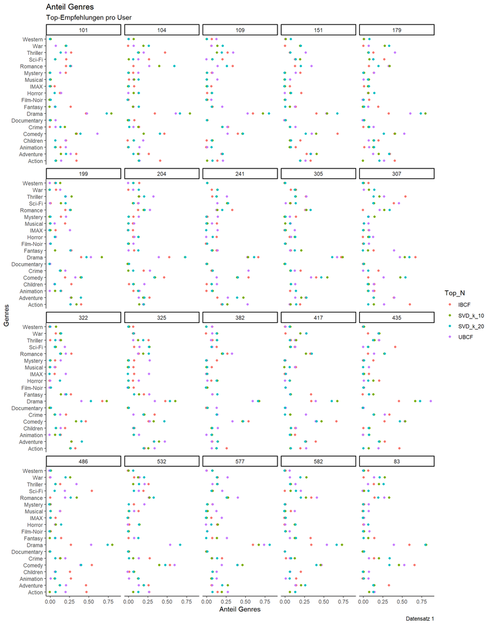

```r
# sample 1
 ggplot(recommender_prop, aes(x=prop, y=genres, color=Top_N)) +
    geom_jitter(width = 0.01, height = 0) +
  facet_wrap(userId  ~ .,ncol = 5)+
   labs(
            title = "Anteil Genres",
            subtitle = "Top-Empfehlungen pro User",
            x = "Anteil Genres",
            y = "Genres",
            caption = "Datensatz 1") +
  theme_classic()
```

```r
# sample 2
IBCF_prop <- get_proportion(pIBCF2,test_data2,"IBCF",genres_sep2)
UBCF_prop <- get_proportion(pUBCF2,test_data2,"UBCF",genres_sep2)
SVD_k_10_prop <- get_proportion(PSVDk_10_2,test_data2,"SVD_k_10",genres_sep2)
SVD_k_20_prop <- get_proportion(PSVDk_20_2,test_data2,"SVD_k_20",genres_sep2)

recommender_prop2 <- rbind(IBCF_prop,UBCF_prop)%>%
  rbind(SVD_k_10_prop)%>%
  rbind(SVD_k_20_prop)
```

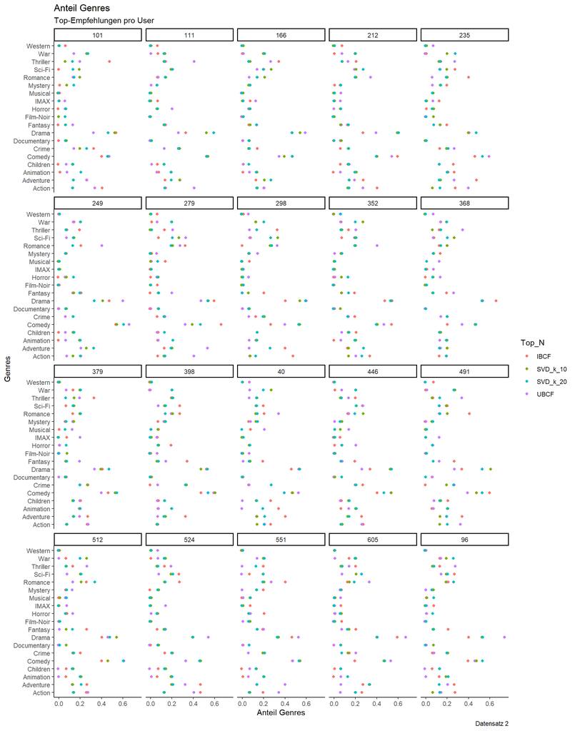

```r
# sample 2
 ggplot(recommender_prop2, aes(x=prop, y=genres, color=Top_N)) +
    geom_jitter(width = 0.01, height = 0) +
  facet_wrap(userId  ~ .)+
   labs(
            title = "Anteil Genres",
            subtitle = "Top-Empfehlungen pro User",
            x = "Anteil Genres",
            y = "Genres",
            caption = "Datensatz 2") +
  theme_classic()
```

**Interpretation:**Der erste Teil von der Hypothese kann bestätigt werden. Der zweite Teil mit den Ähnlichkeiten zwischen UBCF und IBCF wird abgelehnt.

## 11.3 Bestimme pro Kunde den Anteil nach Genres seiner Top-Filme

**Hypothese:** Wir gehen davon aus, dass die meisten User Filme von maximal 5 Genres bewertet und somit angesehen haben.

```r
get_proportion_user <- function(ratings_data,genres_data,test_data){

top_n_user <- ratings_data %>%
  filter(userId %in% rownames(test_data)) %>%
  arrange(desc(z_rating)) %>%
  group_by(userId) %>%
  slice(1:15)%>%
  ungroup() %>%
  select(c(userId,movieId,z_rating)) %>%
  pivot_wider(names_from = movieId, values_from = z_rating)

row_top_n <- top_n_user$userId
top_n_user <- as.matrix(select(top_n_user,-c(userId)))
rownames(top_n_user) <- row_top_n
top_n_user <- top_n_user[, order(as.integer(colnames(top_n_user)))]

top_n_user[is.na(top_n_user) == FALSE] <- 1
top_n_user[is.na(top_n_user)] <- 0

dummies <-genres_data%>%
  filter(movieId %in% colnames(top_n_user))%>%
  dummy_columns(select_columns = "genres") %>%
  select(-c("genres","title"))
dummies <- aggregate(dummies,by=list(name=dummies$movieId), max)
rownames(dummies) <- dummies$movieId
dummies <- as.matrix(select(dummies,-c("movieId","name")))


genres_proportion <- as.data.frame(top_n_user %*% dummies/15)
genres_proportion$userId <- rownames(genres_proportion)
genres_proportion <- genres_proportion %>%
  pivot_longer(!userId, names_to = "genres", values_to = "prop")
genres_proportion$genres <- str_replace_all(genres_proportion$genres, "genres_", "")
genres_proportion$Top_N <- "User"
return(genres_proportion)
}
```

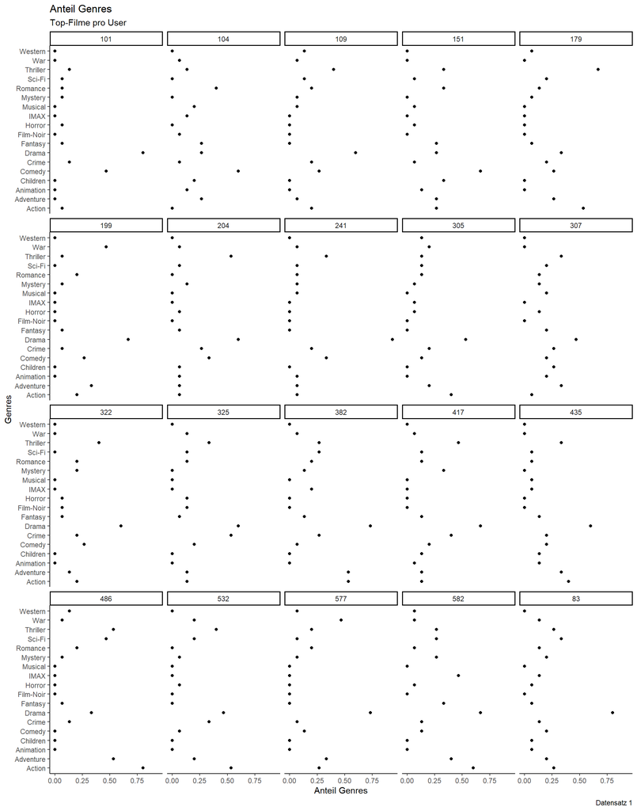

```r
# sample 1
top_n_user1 <- get_proportion_user(norm_ratings1,genres_sep1,test_data)

 ggplot(top_n_user1, aes(x=prop, y=genres)) +
    geom_point() +
  facet_wrap(userId  ~ .)+
   labs(
            title = "Anteil Genres",
            subtitle = "Top-Filme pro User",
            x = "Anteil Genres",
            y = "Genres",
            caption = "Datensatz 1") +
  theme_classic()
```

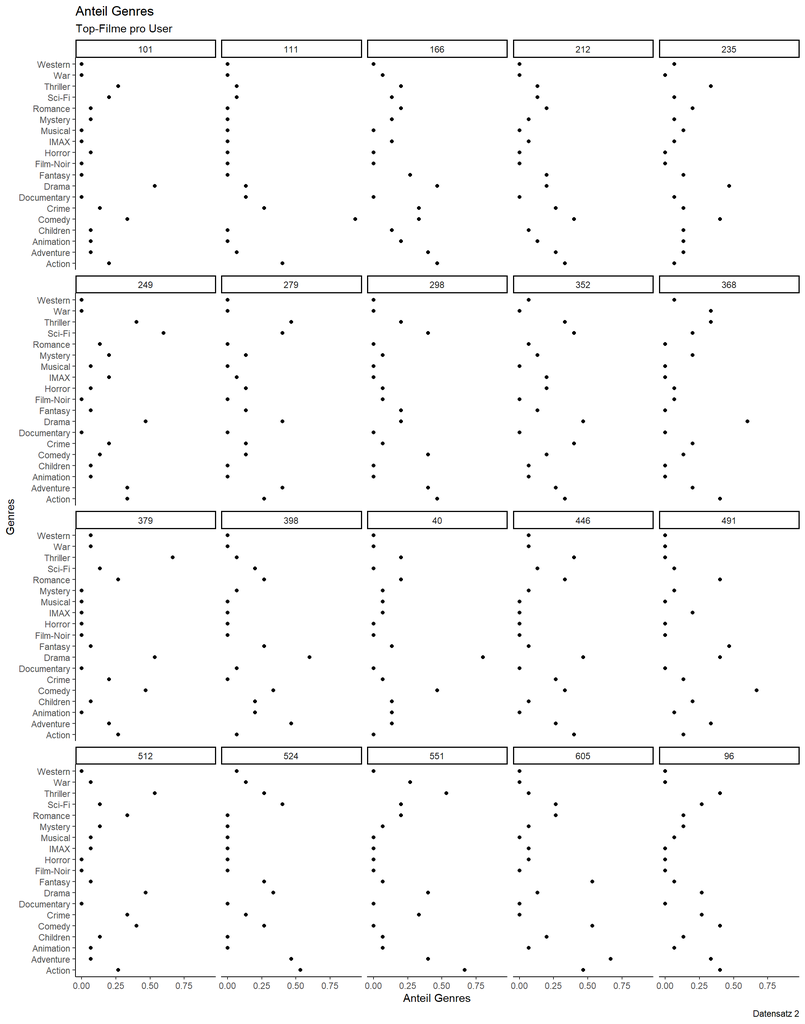

```r
# sample 2
top_n_user2 <- get_proportion_user(norm_ratings2,genres_sep2,test_data2)

ggplot(top_n_user2, aes(x=prop, y=genres)) +
    geom_point() +
  facet_wrap(userId  ~ .)+
   labs(
            title = "Anteil Genres",
            subtitle = "Top-Filme pro User",
            x = "Anteil Genres",
            y = "Genres",
            caption = "Datensatz 2") +
  theme_classic()
```

**Beschreibung:**Die meisten User haben diverse Genres, welche sie nicht interessiert. Es gibt aber auch Kunden wie der User 96 im Datensatz 2, die Filme bei sehr unterschiedlichen Genres angesehen haben.

**Interpretation:** Die Hypothese kann unter vorbehalt bestätigt werden. Die meisten Nutzer konzentrieren sich auf ein paar wenige Genres.

## 11.4 Vergleiche pro Kunde Top-Empfehlungen vs Top-Filme nach Genres

**Hypothese:** Das Profil mit den Top-Empfehlungen liegt zwischen den unterschiedlichen Genres.

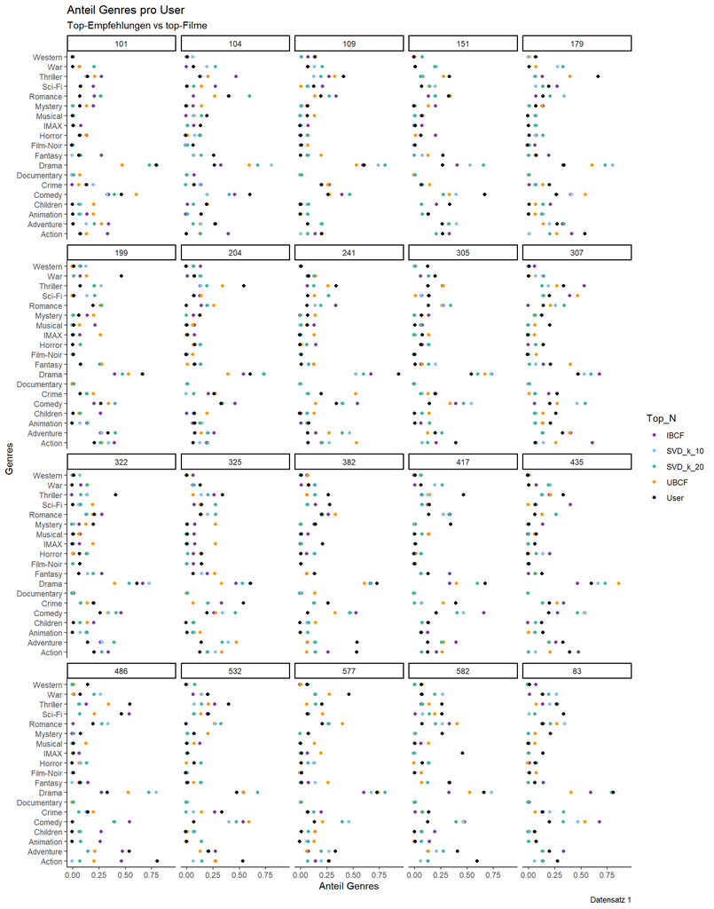

```r
# sample 1
colors <- c("#7d3c98", "#85c1e9", "#45b39d","#f39c12",  "#000000")
recommender_user_prop <- rbind(recommender_prop,top_n_user1)
 ggplot(recommender_user_prop, aes(x=prop, y=genres, color=Top_N)) +

    geom_jitter(width = 0.01, height = 0,alpha = 1) +
   scale_color_manual(values=colors) +
  facet_wrap(userId  ~ .)+
   labs(
            title = "Anteil Genres pro User",
            subtitle = "Top-Empfehlungen vs top-Filme",
            x = "Anteil Genres",
            y = "Genres",
            caption = "Datensatz 1") +
  theme_classic()
```

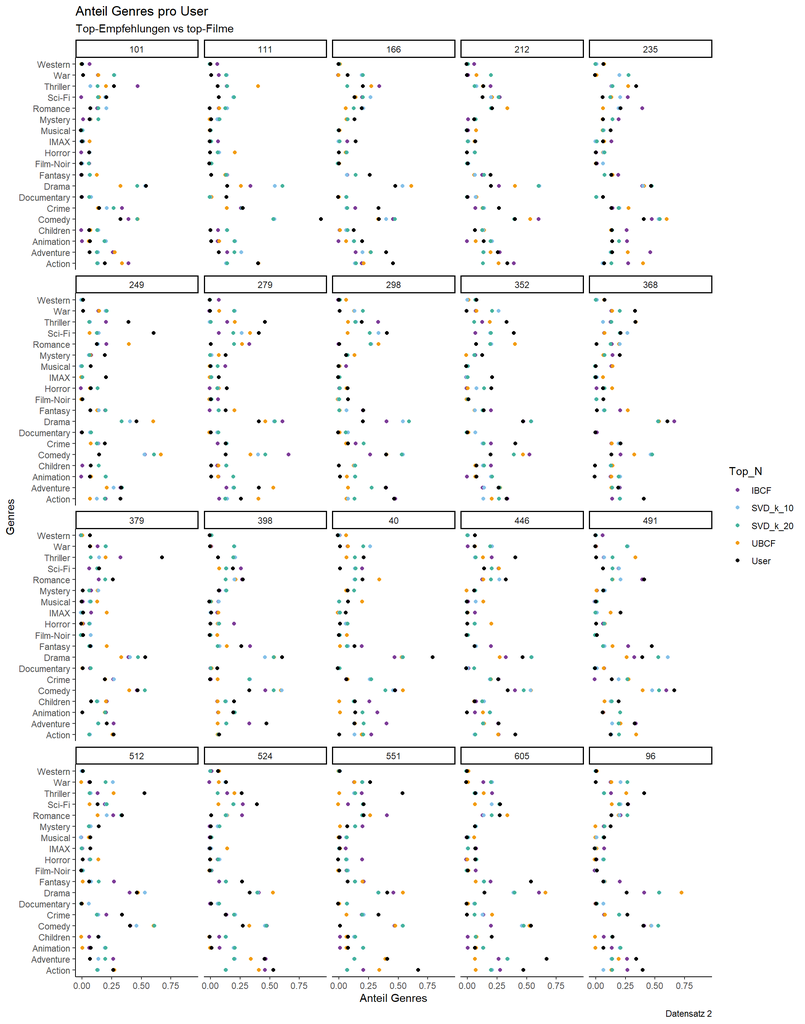

```r
# sample 2
recommender_user_prop2 <- rbind(recommender_prop2,top_n_user2)
 ggplot(recommender_user_prop2, aes(x=prop, y=genres, color=Top_N)) +

    geom_jitter(width = 0.01, height = 0,alpha = 1) +
   scale_color_manual(values=colors) +
  facet_wrap(userId  ~ .,ncol = 5)+
   labs(
            title = "Anteil Genres pro User",
            subtitle = "Top-Empfehlungen vs top-Filme",
            x = "Anteil Genres",
            y = "Genres",
            caption = "Datensatz 2") +
  theme_classic()
```

**Beschreibung:** Das Profil der Top- Empfehlungen liegt nicht immer zwischen den mit den Recommender Systemen berechneten Profilen. Im grossen und ganzen liegen die Profile nahe beieinander.

**Interpretation:**Die Hypothese kann zwar abgelehnt werden. Trotzdem funktionieren die Recommender nicht schlecht. Sie sollten auch nicht unbedingt um das Top- Empfehlungen Profil streuen. Dann würden wahrscheinlich zuviele Blockbuster vorhergesagt werden.

## 11.5 Definiere eine Qualitätsmetrik für Top-N Listen und teste sie.

**Erklärung der Auswahl der Qualitätsmetrik:**

Um den Anteil von Genres zu vergleichen gibt es unterschiedliche Möglichkeiten. Zum einem könnte man, wieder ein Ähnlichkeitsmass verwenden. Es ist es auch möglich ein Distanzmass zu verwenden. Eine Herausforderung besteht darin, dass jeder Filme diverse Genres haben kann. Das führt zu einem Rauschen in den Daten. Ein Action Liebhaber könnte einen Action- Film geschaut haben, welcher auch dem Genre Romantik zugewiesen ist. Wenn er 10 Action Filme geschaut hat, sollte der Anteil von Romantik keinen Einfluss haben.

Das führt zu einem Problem mit beiden Metriken. Die Genres die der User sehr stark mag, werden nicht zusätzlich Gewichtet. Darum verwenden wir in diesem Abschnitt die L2- Norm von den 3 Genres mit dem grössten Anteil.

```r
# Sample 1
top3_1 <- recommender_user_prop %>%
  pivot_wider(names_from = Top_N, values_from = prop) %>%
  arrange(desc(User)) %>%
  group_by(userId)%>%
  slice(1:3)


recommender <- list("IBCF", "UBCF" ,"SVD_k_10", "SVD_k_20")
top3_metrik <- list()
for (rec in recommender){
 top3_metrik <- append(top3_metrik,norm(top3_1$User - top3_1[[rec]],type="2"))
}
```

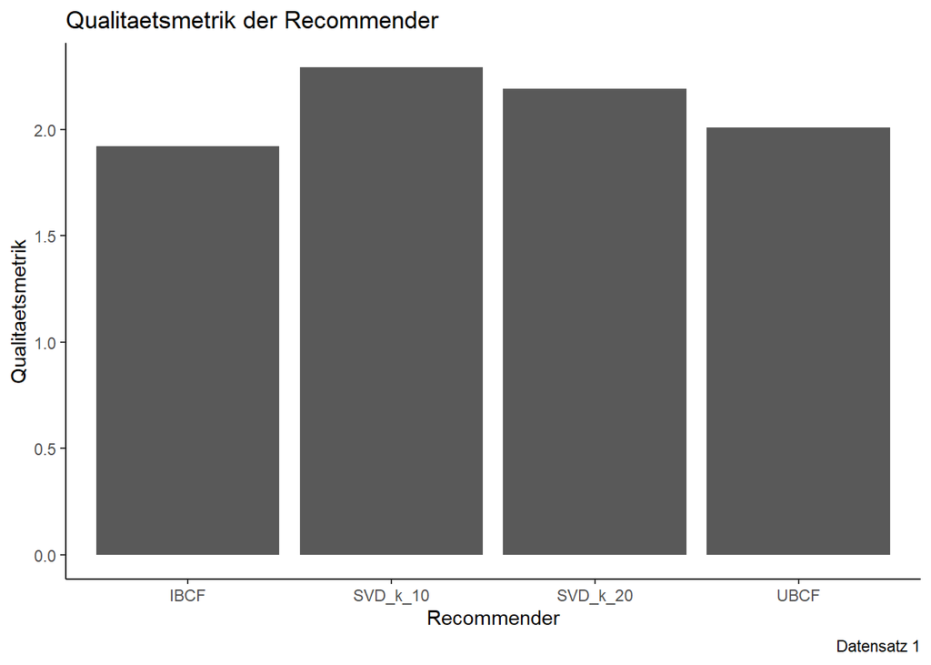

```r
# Sample 1
do.call(rbind, Map(data.frame, Top3Metrik=top3_metrik, Recommender=recommender)) %>%
          ggplot(., aes(Recommender,Top3Metrik)) +
                geom_bar(stat = "identity")+
          labs(
            title = "Qualitaetsmetrik der Recommender",
            x = "Recommender",
            y = "Qualitaetsmetrik",
            caption = "Datensatz 1") +
  theme_classic()
```

```r
# Sample 2
top3_2 <- recommender_user_prop2 %>%
  pivot_wider(names_from = Top_N, values_from = prop) %>%
  arrange(desc(User)) %>%
  group_by(userId)%>%
  slice(1:3)


recommender <- list("IBCF", "UBCF" ,"SVD_k_10", "SVD_k_20")
top3_metrik <- list()
for (rec in recommender){
 top3_metrik <- append(top3_metrik,norm(top3_2$User - top3_2[[rec]], type = "2"))
}
```

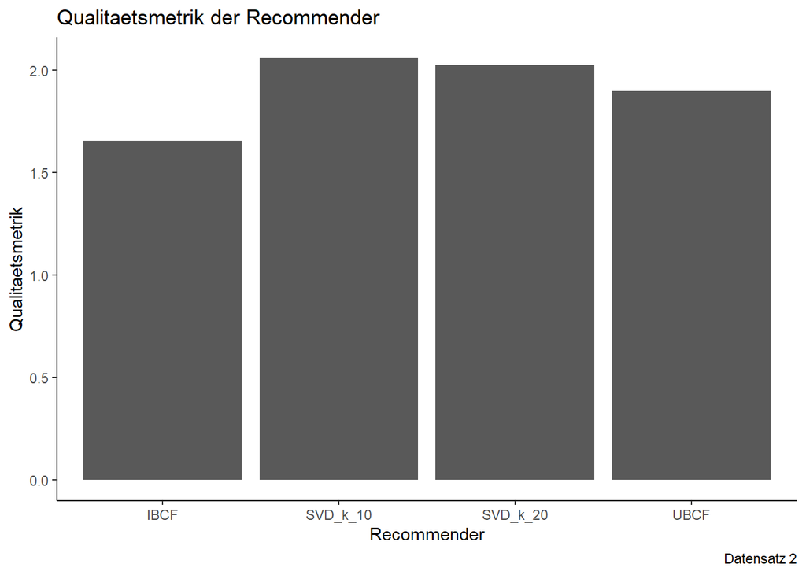

```r
# Sample 2
do.call(rbind, Map(data.frame, Top3Metrik=top3_metrik, Recommender=recommender)) %>%
          ggplot(., aes(Recommender,Top3Metrik)) +
                geom_bar(stat = "identity") +
          labs(
            title = "Qualitaetsmetrik der Recommender",
            x = "Recommender",
            y = "Qualitaetsmetrik",
            caption = "Datensatz 2") +
  theme_classic()
```

**Beschreibung:** Der IBCF-Recommender hat in beiden Daten den tiefsten Wert. Die SVD-Recommender mit den 10 und 20 Singulärwerten haben die höchsten Werte.

**Interpretation:** Was diese Metrik anbelangt erziehlt der IBCF Recommender die besten Resultate. Eine absolute Aussage kann nicht getroffen werden, da es nur mit den 20 Nutzern ausgewertet wurde.

# 12 Fazit

Es war spannend zu sehen wie die unterschiedlichen Recommender Systeme aufgebaut sind. Für uns war die grosse Erkentnisse, dass die Evaluierung von Recommender Systemen nicht einfach ist. Um ein optimaler Recommender zu finden müsste man stärker mit Rückmeldung von Usern arbeiten. Zudem war es wahrscheinlich vom Vorgehen nicht optimal, die Ratings zu standartisieren.